# Extensions to Regression Model

## Polynomial Regression

### model:

simple case: $x$ is one dimensional

$\hat{y_i} = \beta_0 + \beta_1 x_i + \beta_2 x_i^2 + ... + \beta_d x_i^d$

### predictors:

- $X = \begin{bmatrix} 1 & x_{1} & x_{1}^2 & x_{1}^3 & \dots & x_{1}^d \\ 1 & x_{2} & x_{2}^2 & x_{2}^3 & \dots & x_{2}^d \\ \vdots & \vdots & \vdots & \vdots & \ddots & \vdots \\ 1 & x_{i} & x_{i}^2 & x_{i}^3 & \dots & x_{i}^d \\ \vdots & \vdots & \vdots & \vdots & \ddots & \vdots \\ 1 & x_{N} & x_{N}^2 & x_{N}^3 & \dots & x_{N}^d \end{bmatrix}$

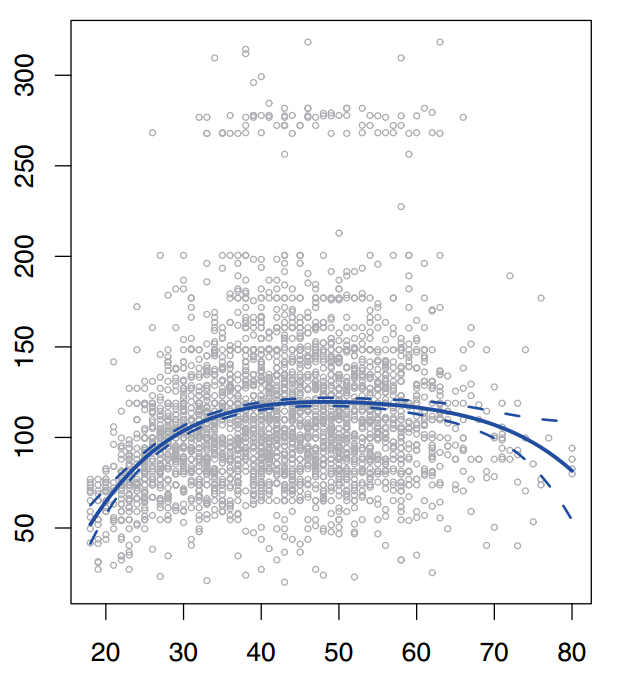

# Residual Diagnostics

Assumptions of linear regression

- Linear relationship
- Normality
- Homogeneous variance
- Independent observations

How to check?

- Residual plot
- Q-Q plot
- Also need to check residuals for outliers, influencial points, high leverage points

Magnitude or even sign of the coefficient could be wrong if did not carefully check for residuals

What to do if residuals do not match assumptions?

- Transformation of X and/or Y
- Weighted Least Square Model
- Non-independece: time series model

## Transformations

```r
set.seed(2)
N = 300
x1 = rnorm(N, 0, 1)
x2 = rpois(N, 3)
x2 = ifelse(x2>0, x2, 1)
x3 = runif(N, 5,15)

# Ex1 Transform X
y = 0.3 + 0.6 * x1 + 2 * log(x2) + rnorm(N, 0, 0.5)

mod = lm(y ~ x1 + x2)
summary(mod)
```

```
##
## Call:
## lm(formula = y ~ x1 + x2)
##
## Residuals:
##      Min       1Q   Median       3Q      Max
## -1.83731 -0.39923  0.01142  0.40446  1.65085
##
## Coefficients:
##             Estimate Std. Error t value Pr(>|t|)
## (Intercept)  0.17198    0.07352   2.339     0.02 *
## x1           0.62848    0.03315  18.956   <2e-16 ***
## x2           0.67130    0.02141  31.361   <2e-16 ***
## ---
## Signif. codes:  0 '***' 0.001 '**' 0.01 '*' 0.05 '.' 0.1 ' ' 1
##
## Residual standard error: 0.6126 on 297 degrees of freedom
## Multiple R-squared:  0.8186, Adjusted R-squared:  0.8173
## F-statistic: 669.9 on 2 and 297 DF,  p-value: < 2.2e-16
```

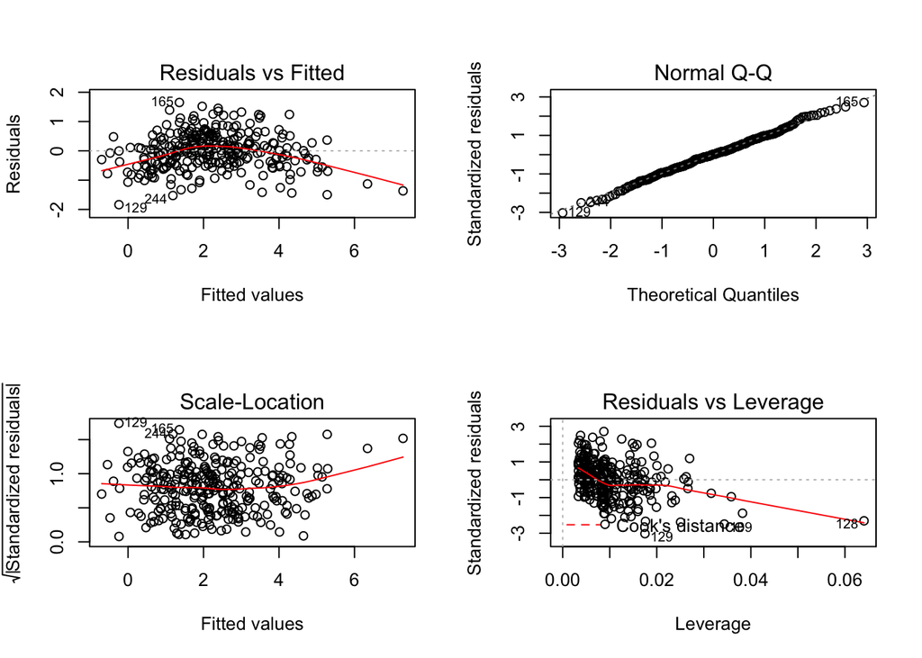

```r
par(mfrow = c(2,2))
plot(mod)
```

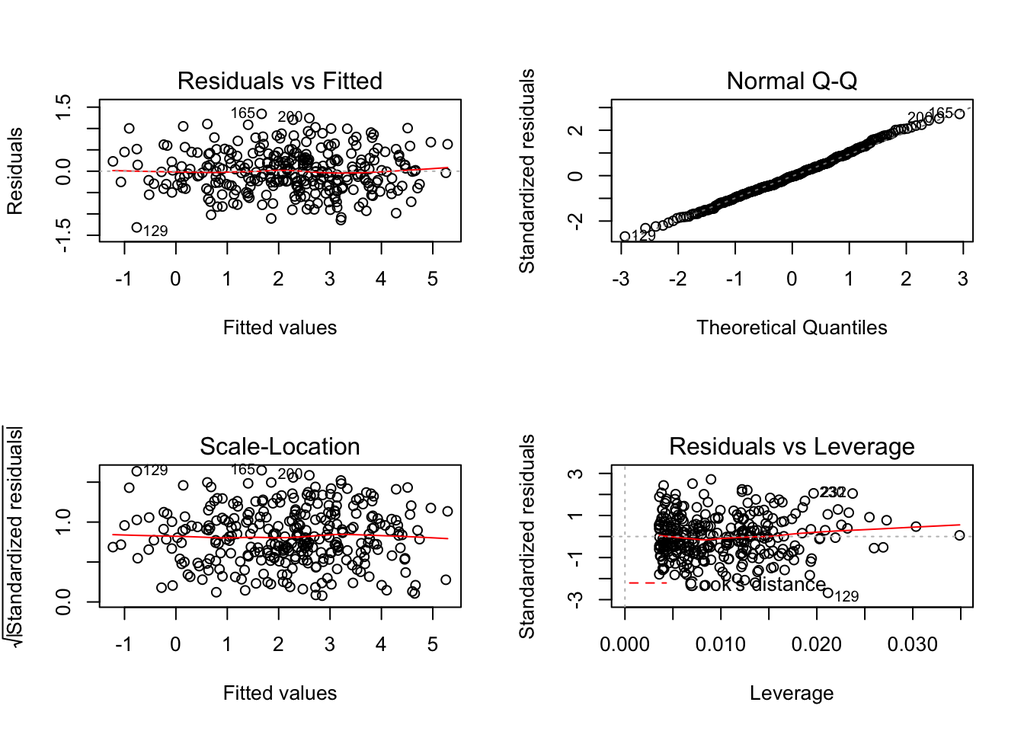

```r
#residual vs. fitted value plot is not linear, QQ plot is OK, try log transformation of X
mod = lm(y ~ x1 + log(x2))
plot(mod)
```

```r
# Ex2 Polynomial X
y = 0.3 + x1 + 0.8 * x1^2 + rnorm(N, 0, 0.5)

mod = lm(y ~ x1)
summary(mod)
```

```
##
## Call:
## lm(formula = y ~ x1)
##
## Residuals:
##     Min      1Q  Median      3Q     Max
## -2.6354 -0.8600 -0.3648  0.5768  5.6859
##
## Coefficients:
##             Estimate Std. Error t value Pr(>|t|)
## (Intercept)  1.21869    0.07284   16.73   <2e-16 ***
## x1           1.11569    0.06822   16.36   <2e-16 ***
## ---
## Signif. codes:  0 '***' 0.001 '**' 0.01 '*' 0.05 '.' 0.1 ' ' 1
##
## Residual standard error: 1.26 on 298 degrees of freedom
## Multiple R-squared:  0.473,  Adjusted R-squared:  0.4712
## F-statistic: 267.5 on 1 and 298 DF,  p-value: < 2.2e-16
```

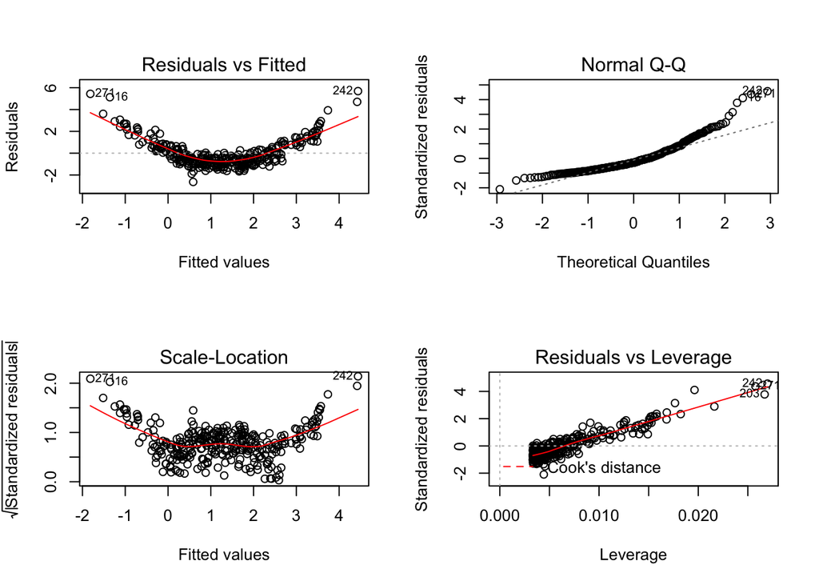

```r
par(mfrow = c(2,2))
plot(mod)
```

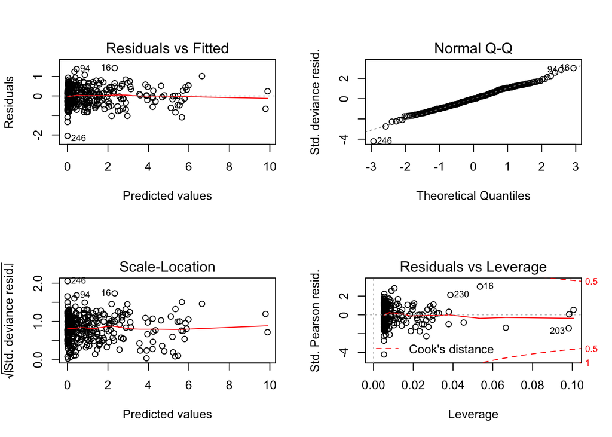

```r
#clearly non-linear relationship, but equal variance, try adding polynomial terms of X
mod = glm(y ~ x1 + I(x1^2))
plot(mod)
```

```r
# example of 3rd order
y = 0.3 + x1 + x1^2 + x1^3 + rnorm(N, 0, 0.5)

mod = lm(y ~ x1)
summary(mod)
```

```
##
## Call:
## lm(formula = y ~ x1)
##
## Residuals:
##     Min      1Q  Median      3Q     Max
## -5.3757 -2.0420 -0.3581  1.4747 22.2253
##
## Coefficients:
##             Estimate Std. Error t value Pr(>|t|)
## (Intercept)   1.5363     0.1616   9.505   <2e-16 ***
## x1            4.1645     0.1514  27.514   <2e-16 ***
## ---
## Signif. codes:  0 '***' 0.001 '**' 0.01 '*' 0.05 '.' 0.1 ' ' 1
##
## Residual standard error: 2.797 on 298 degrees of freedom
## Multiple R-squared:  0.7175, Adjusted R-squared:  0.7166
## F-statistic:   757 on 1 and 298 DF,  p-value: < 2.2e-16
```

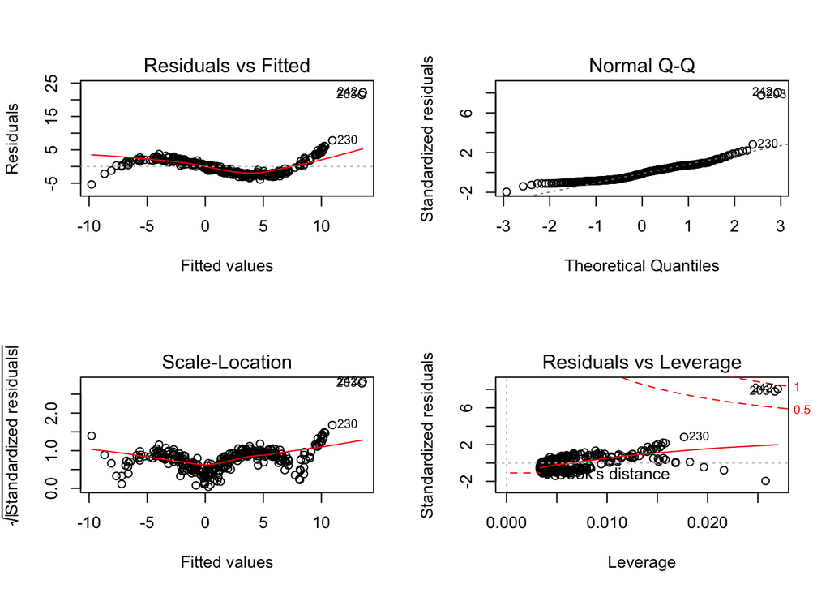

```r
par(mfrow = c(2,2))
plot(mod)
```

```r
# Ex3 transform Y
y = exp(0.6 + 0.3 * x1 + rnorm(N, 0, 0.5))

mod = lm(y ~ x1 )
summary(mod)
```

```
##
## Call:
## lm(formula = y ~ x1)
##
## Residuals:
##     Min      1Q  Median      3Q     Max
## -2.2815 -0.7994 -0.2040  0.4688  6.4049
##
## Coefficients:
##             Estimate Std. Error t value Pr(>|t|)
## (Intercept)  2.13681    0.06811   31.37   <2e-16 ***
## x1           0.68292    0.06379   10.71   <2e-16 ***
## ---
## Signif. codes:  0 '***' 0.001 '**' 0.01 '*' 0.05 '.' 0.1 ' ' 1
##
## Residual standard error: 1.179 on 298 degrees of freedom
## Multiple R-squared:  0.2778, Adjusted R-squared:  0.2753
## F-statistic: 114.6 on 1 and 298 DF,  p-value: < 2.2e-16
```

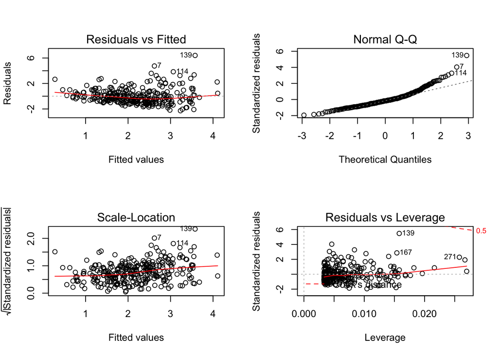

```r
par(mfrow = c(2,2))
plot(mod)
```

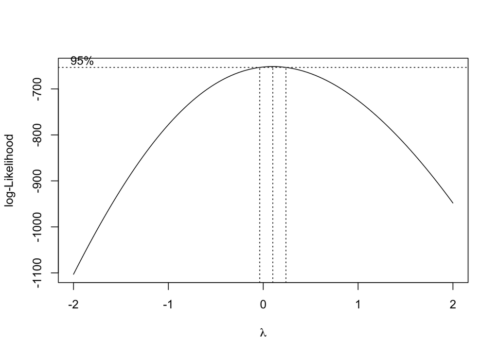

```r
#residual has a fan shape (variance increase as fitted value), try transform on Y
library(MASS)
par(mfrow = c(1,1))
boxcox(mod)
```

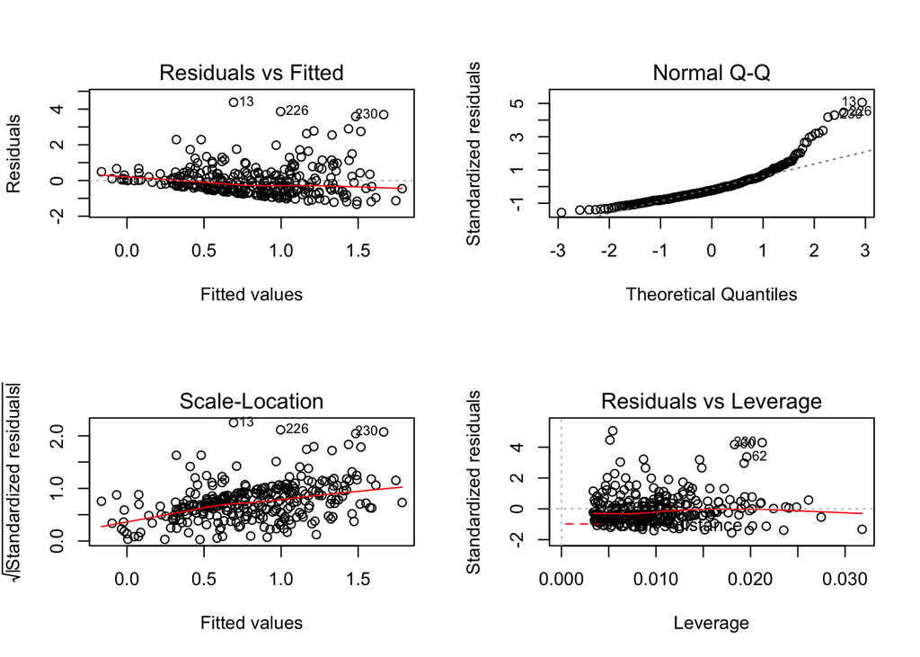

```r
# boxcox is a way for identifying best y transformation,
# lamba = 0 suggest log transform, 1 orginal, 1/2 sqrt, -1 inverse
# result is 0

# example of sqrt of Y
y = (0.6 + 0.3 * x1 + rnorm(N, 0, 0.5))^2

mod = lm(y ~ x1 + x3 )
par(mfrow = c(2,2))
plot(mod)
```

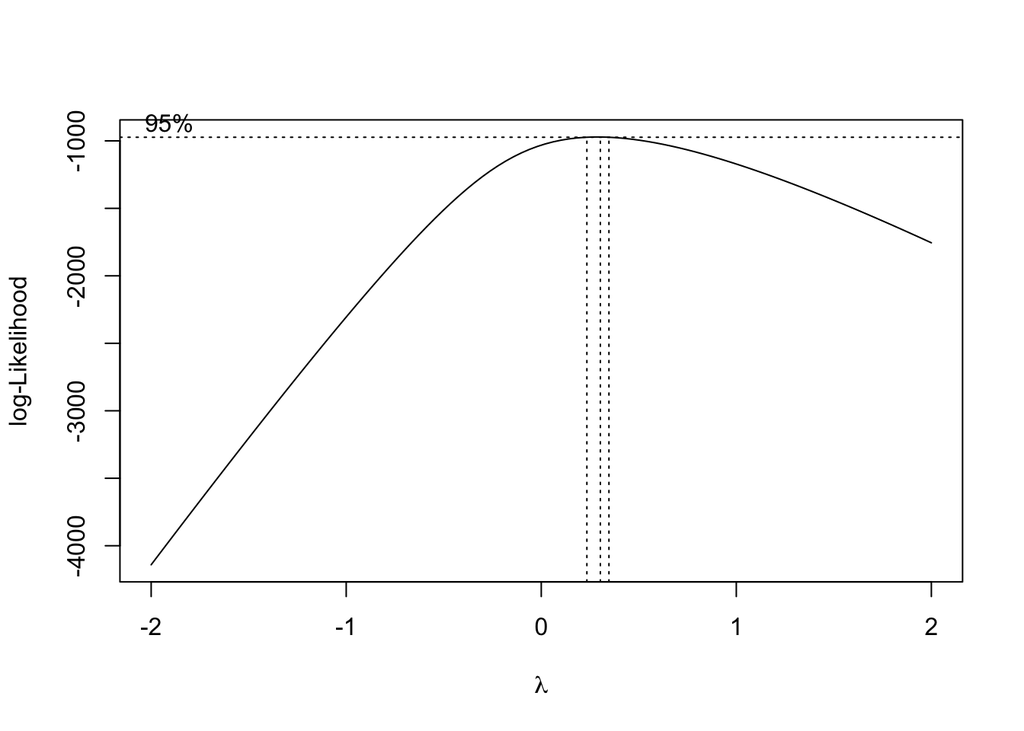

```r
par(mfrow = c(1,1))
boxcox(mod)
```

This link summarized good examples https://onlinecourses.science.psu.edu/stat501/node/322

## Bias Variance Tradeoff

$Y = f(X) + \text{noise}$

$E[(Y - \hat{f}(X))^2] = Bias(\hat{f}(X))^2 + Var(\hat{f}(X)) + \text{noise term}$

$Bias(\hat{f}(X)) = E[\hat{f}(X) - f(X)]$

$Var(\hat{f}(X)) = E[\hat{f}(X)^2] - E[\hat{f}(X)]^2$

There is trade-off between bias & variance

- Low Bias: linear model fit linear data
- High Bias: linear model fit non-linear data
- Low Variance: model little dependent on train data
- High Variance: model highly dependent on train data
- Low Bias: build complex model for complex data
- Low Variance: Average your model

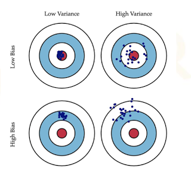

Chase for low bias and ignore high variance may cause overfitting problem

## Overfitting

- learning noise rather than data
- “fitting complex” model on “simple data”
- good performance on training set bad performance on testing set
- usually large coefficients in regression model

remind LSE $\hat{\beta} = (X^TX)^{-1}X^Ty$

### Control Overfitting

- use more data
- regularization
- Subset Selection
- dimensionality reduction

## Interaction Terms

When to add interaction terms? - It is not good recommended to add all interaction terms into model (overfitting, computational complexity) - Come up hypothesis with domain knowledge & intuition, e.g. price sensitivity is different based on user’s income, thus add interaction of price * income - Test your hypothesis by adding interaction term into model and check for significance or do variable selection

## Regression Splines

Examples Kids will grow about 2 inches and gain 4 pounds each year until puberty (usually between 8 and 13 for girls and 10 and 14 for boys). Girls often reach their full height around 15. Boys usually hit their adult height around age 17

### Step Function Model:

$\hat{y_i} = \beta_0 + \beta_1 C_1(x_i) + \beta_2 C_2(x_i) + ... + \beta_K C_K(x_i)$

### predictors:

- $X = \begin{bmatrix} 1 & C_1(x_{1}) & C_2(x_{1}) & C_3(x_{1}) & \dots & C_K(x_{1}) \\ 1 & C_1(x_{2}) & C_2(x_{2}) & C_3(x_{2}) & \dots & C_K(x_{2}) \\ \vdots & \vdots & \vdots & \vdots & \ddots & \vdots \\ 1 & C_1(x_{i}) & C_2(x_{i}) & C_3(x_{i}) & \dots & C_K(x_{i}) \\ \vdots & \vdots & \vdots & \vdots & \ddots & \vdots \\ 1 & C_1(x_{N}) & C_2(x_{N}) & C_3(x_{N}) & \dots & C_K(x_{N}) \end{bmatrix}$

### best $\beta$

Least square minimize MSE

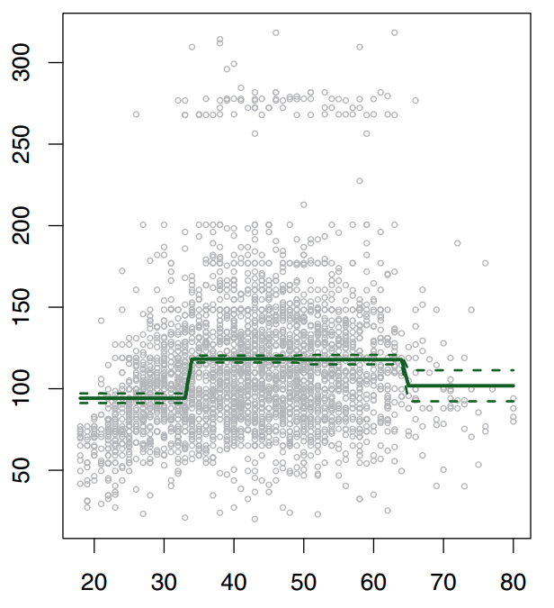

### Basic Function:

$\hat{y_i} = \beta_0 + \beta_1 b_1(x_i) + \beta_2 b_2(x_i) + ... + \beta_K b_K(x_i)$

so step function model and polynomial model are just special case of basic function.

### Regression Splines

Like piecewise polynomial regression, but with constraints on knots(where coefficient changes).

$\hat{y_i} = \beta_0 + \beta_1 x_i + \beta_2 x_i^2 + ... + \beta_d x_i^d + \beta_{d+1}(x_i - \xi_1)_{+}^m + ... + \beta_{d+K} (x_i - \xi_K)_{+}^m$

In order to achieve continuity, we need to add this feature(truncated power basis)

$$(x - \xi)_{+}^m = \begin{cases}
0 & x\leq \xi \\
(x - \xi)^m & x > \xi
\end{cases}$$

### predictors:

- $X = \begin{bmatrix} 1 & x_{1} & x_{1}^2 & x_{1}^3 & \dots & (x_1 - \xi_1)_{+}^m & \dots & (x_1 - \xi_K)_{+}^m \\ 1 & x_{2} & x_{2}^2 & x_{2}^3 & \dots & (x_2 - \xi_1)_{+}^m & \dots & (x_2 - \xi_K)_{+}^m \\ \vdots & \vdots & \vdots & \vdots & \ddots & \vdots & \dots & \vdots \\ 1 & x_{i} & x_{i}^2 & x_{i}^3 & \dots & (x_i - \xi_1)_{+}^m & \dots & (x_i - \xi_K)_{+}^m \\ \vdots & \vdots & \vdots & \vdots & \ddots & \vdots & \dots & \vdots \\ 1 & x_{N} & x_{N}^2 & x_{N}^3 & \dots & (x_N - \xi_1)_{+}^m & \dots & (x_N - \xi_K)_{+}^m \end{bmatrix}$

### best $\beta$

Least square minimize MSE

Usually, we choose polynomial degree to be 3, known as cubic spline, basically human cannot recognize discontinuity at degree of 3.

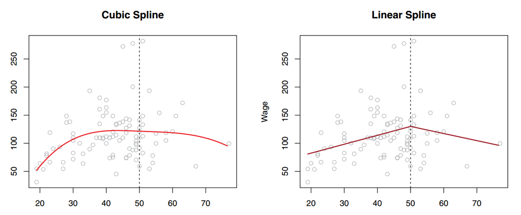